# Take-Home Exercise 3

Analysis and display of Engagement’s economy.

Yeo Kim Siang https://www.linkedin.com/in/kim-siang-yeo-b42317134/ (Singapore Management University)https://scis.smu.edu.sg/master-it-business  
2022-05-15

# The Task

This [takehome exercise](https://isss608-ay2021-22april.netlify.app/th_ex/th_ex03) aims to sharpen the skill of building data visualisation programmatically using appropriate tidyverse family of packages and the preparation of statistical graphics using ggplot2 and its extensions. The specifc requirements can be found in the screenshot below.

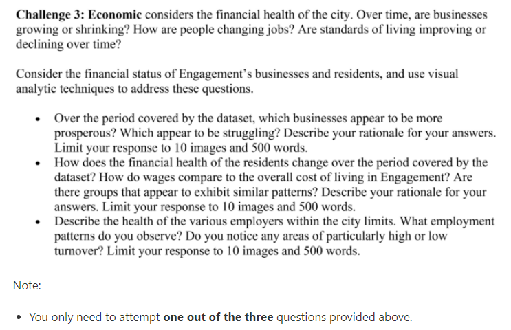

You can find the links to then datasets [here](https://vast-challenge.github.io/2022/).

# Chosen Question

My analysis will focus on the Question 2.

*“How does the financial health of the residents change over the period covered by the dataset? How do wages compare to the overall cost of living in Engagement? Are there groups that appear to exhibit similar patterns? Describe your rationale for your answers. Limit your response to 10 images and 500 words.”*

# Approach

I will focus on the dataset *FinancialJournal* since it contains all the information I need.

To guide my exploration, I will remove all ambiguity by defining what financial health means.

Financial health is defined as a state of

1. A steady flow of income To determine this, we can use the “Category” called “Wage” from the dataset *FinancialJournal.*
2. Rare changes in expenses To determine this, we can use the “Category” called “Education”, “Food”, “Recreation” and “Shelter” from the dataset *FinancialJournal.*
3. A cash balance that is growing. To determine this, we can use the difference between income and the different types of costs in the dataset *FinancialJournal.*

I will use Trellisplotjs to survey the data and pick out on certain peculiarties.

Based on the insights discovered, I will try to create a unifying visualisation solution.

# Basic Exploration

Having locked down our approach, we use it as a guide to explore the data using [R for Data Science](https://r4ds.had.co.nz/exploratory-data-analysis.html) as a guide.

## Initialisation

### Getting Packages

The packages required are tidyverse, trelliscopejs, ggplot2, and gapminder.

The code chunk below is used to install and load the required packages onto RStudio.

```r
packages = c('tidyverse', 'trelliscopejs', 'ggplot2', 'gapminder', 'lubridate', 'dplyr')
for(p in packages){
  if(!require(p,character.only = T)){
    install.packages(p)
  }
  library(p,character.only = T)
}
```

### Getting Data

The main dataset used is *FinancialJournal.* We use the read_csv() of the readr package is used to import the data.

```r
financialJournal <- read_csv("data/FinancialJournal.csv")
glimpse(financialJournal)
```

```
Rows: 1,047,462
Columns: 4
$ participantId <dbl> 0, 0, 0, 1, 1, 1, 2, 2, 2, 3, 3, 3, 4, 4, 4, 5~
$ timestamp     <dttm> 2022-03-01, 2022-03-01, 2022-03-01, 2022-03-0~
$ category      <chr> "Wage", "Shelter", "Education", "Wage", "Shelt~
$ amount        <dbl> 2472.50756, -554.98862, -38.00538, 2046.56221,~
```

We also convert the data into RDS format since it exceeded Git’s recommended memory limits.

```r
saveRDS(financialJournal, 'data/financialJournal.rds')
financialJournal <- readRDS('data/financialJournal.rds')
head(financialJournal)
```

```
# A tibble: 6 x 4
  participantId timestamp           category  amount
          <dbl> <dttm>              <chr>      <dbl>
1             0 2022-03-01 00:00:00 Wage      2473.
2             0 2022-03-01 00:00:00 Shelter   -555.
3             0 2022-03-01 00:00:00 Education  -38.0
4             1 2022-03-01 00:00:00 Wage      2047.
5             1 2022-03-01 00:00:00 Shelter   -555.
6             1 2022-03-01 00:00:00 Education  -38.0
```

## Getting Trelliscopejs

Instead of going through the trouble of mutating data and creating facet plots, we use Trelliscopejs.

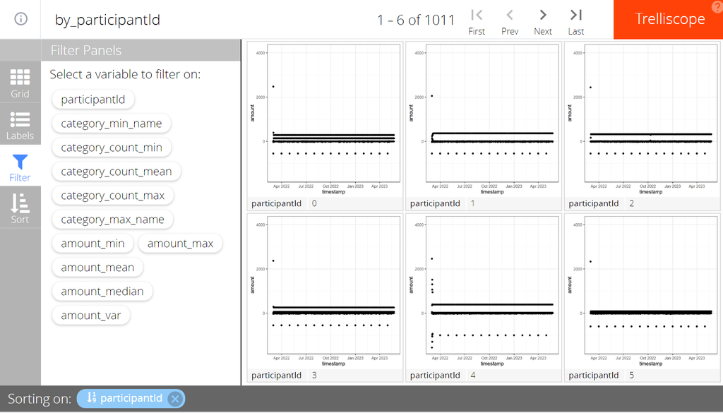

```r
qplot(timestamp, amount, data = financialJournal) +
  theme_bw() +
  facet_trelliscope(~ participantId,
                    nrow = 2,
                    ncol = 5,
                    path = "trellis/",
                    self_contained = TRUE)
```

The Trelliscopejs result from using the dataset *FinancialJournal* in full yielded a result that was not useful. That was because all categories were clunked together. Also, a quick look at the original CSV file shows that there were duplicate values.

Instead, I manually cleaned the CSV file. Next, I created datasets for each category using the code chunk below.

```r
# Creating sub-dataset for the category "Education"
educationExpense <- filter(financialJournal, category == 'Education')
head(educationExpense)
```

```
# A tibble: 6 x 4
  participantId timestamp           category  amount
          <dbl> <dttm>              <chr>      <dbl>
1             0 2022-03-01 00:00:00 Education  -38.0
2             1 2022-03-01 00:00:00 Education  -38.0
3             2 2022-03-01 00:00:00 Education  -12.8
4             3 2022-03-01 00:00:00 Education  -38.0
5             4 2022-03-01 00:00:00 Education  -12.8
6             5 2022-03-01 00:00:00 Education  -12.8
```

```r
# Creating sub-dataset for the category "Food"
foodExpense <- filter(financialJournal, category == 'Food')
head(foodExpense)
```

```
# A tibble: 6 x 4
  participantId timestamp           category amount
          <dbl> <dttm>              <chr>     <dbl>
1           728 2022-03-01 04:50:00 Food         -4
2           534 2022-03-01 05:30:00 Food         -4
3           507 2022-03-01 05:30:00 Food         -4
4           616 2022-03-01 05:40:00 Food         -4
5           500 2022-03-01 05:40:00 Food         -4
6           699 2022-03-01 05:45:00 Food         -4
```

```r
# Creating sub-dataset for the category "Recreation"
recreationExpense <- filter(financialJournal, category == 'Recreation')
head(recreationExpense)
```

```
# A tibble: 6 x 4
  participantId timestamp           category   amount
          <dbl> <dttm>              <chr>       <dbl>
1            23 2022-03-01 06:00:00 Recreation  -1.03
2            23 2022-03-01 06:50:00 Recreation  -4.10
3            15 2022-03-01 07:05:00 Recreation -14.4
4           930 2022-03-01 07:15:00 Recreation -11.6
5           619 2022-03-01 07:20:00 Recreation -20.2
6           359 2022-03-01 07:40:00 Recreation -22.3
```

```r
# Creating sub-dataset for the category "Shelter"
shelterExpense <- filter(financialJournal, category == 'Shelter')
head(shelterExpense)
```

```
# A tibble: 6 x 4
  participantId timestamp           category amount
          <dbl> <dttm>              <chr>     <dbl>
1             0 2022-03-01 00:00:00 Shelter   -555.
2             1 2022-03-01 00:00:00 Shelter   -555.
3             2 2022-03-01 00:00:00 Shelter   -557.
4             3 2022-03-01 00:00:00 Shelter   -555.
5             4 2022-03-01 00:00:00 Shelter  -1556.
6             5 2022-03-01 00:00:00 Shelter   -600.
```

```r
# Creating sub-dataset for the category "Wage"
wageIncome <- filter(financialJournal, category == 'Wage')
head(wageIncome)
```

```
# A tibble: 6 x 4
  participantId timestamp           category amount
          <dbl> <dttm>              <chr>     <dbl>
1             0 2022-03-01 00:00:00 Wage      2473.
2             1 2022-03-01 00:00:00 Wage      2047.
3             2 2022-03-01 00:00:00 Wage      2437.
4             3 2022-03-01 00:00:00 Wage      2367.
5             4 2022-03-01 00:00:00 Wage      2457.
6             5 2022-03-01 00:00:00 Wage      2329.
```

```r
# Adding this for quick run
wageIncome <- filter(financialJournal, category == 'Wage')
head(wageIncome)
```

```
# A tibble: 6 x 4
  participantId timestamp           category amount
          <dbl> <dttm>              <chr>     <dbl>
1             0 2022-03-01 00:00:00 Wage      2473.
2             1 2022-03-01 00:00:00 Wage      2047.
3             2 2022-03-01 00:00:00 Wage      2437.
4             3 2022-03-01 00:00:00 Wage      2367.
5             4 2022-03-01 00:00:00 Wage      2457.
6             5 2022-03-01 00:00:00 Wage      2329.
```

Lastly, I create individual Trelliscopejs plots for each category using the follow code chunks. I run them individually to make it easier to see which is which.

```r
# For education expense
qplot(timestamp, amount, data = educationExpense) +
  theme_bw() +
  facet_trelliscope(~ participantId,
                    nrow = 2,
                    ncol = 5,
                    path = "trellisedu/",
                    self_contained = TRUE)
```

```r
# For food expense
qplot(timestamp, amount, data = foodExpense) +
  theme_bw() +
  facet_trelliscope(~ participantId,
                    nrow = 2,
                    ncol = 5,
                    path = "trellisfd/",
                    self_contained = TRUE)
```

```r
# For recreation expense
qplot(timestamp, amount, data = recreationExpense) +
  theme_bw() +
  facet_trelliscope(~ participantId,
                    nrow = 2,
                    ncol = 5,
                    path = "trellisrec/",
                    self_contained = TRUE)
```

```r
# For shelter expense
qplot(timestamp, amount, data = shelterExpense) +
  theme_bw() +
  facet_trelliscope(~ participantId,
                    nrow = 2,
                    ncol = 5,
                    path = "trellisshel/",
                    self_contained = TRUE)
```

```r
# For wage income
qplot(timestamp, amount, data = wageIncome) +
  theme_bw() +
  facet_trelliscope(~ participantId,
                    nrow = 2,
                    ncol = 5,
                    path = "trelliswage/",
                    self_contained = TRUE)
```

I noticed that I was missing something huge. I did not calculate the sum of the expense of all participants in Engagement.

First, I filter away all income data using the code chunk below.

```r
# Get all expense related data
allExpense <- filter(financialJournal, !(category == 'Wage'))
head(allExpense)
```

```
# A tibble: 6 x 4
  participantId timestamp           category  amount
          <dbl> <dttm>              <chr>      <dbl>
1             0 2022-03-01 00:00:00 Shelter   -555.
2             0 2022-03-01 00:00:00 Education  -38.0
3             1 2022-03-01 00:00:00 Shelter   -555.
4             1 2022-03-01 00:00:00 Education  -38.0
5             2 2022-03-01 00:00:00 Shelter   -557.
6             2 2022-03-01 00:00:00 Education  -12.8
```

```r
# Create a new data.frame with the newly formatted date field
allExpense <- allExpense %>%
  mutate(timestamp = as.Date(timestamp, format = "%m/%d/%y"))
head(allExpense)
```

```
# A tibble: 6 x 4
  participantId timestamp  category  amount
          <dbl> <date>     <chr>      <dbl>
1             0 2022-03-01 Shelter   -555.
2             0 2022-03-01 Education  -38.0
3             1 2022-03-01 Shelter   -555.
4             1 2022-03-01 Education  -38.0
5             2 2022-03-01 Shelter   -557.
6             2 2022-03-01 Education  -12.8
```

Now, we sum all values in the *category* column.

```r
allExpense <- allExpense %>%
  group_by(participantId, timestamp) %>%
  summarise(amount = sum(amount, na.rm = TRUE))
head(allExpense)
```

```
# A tibble: 6 x 3
# Groups:   participantId [1]
  participantId timestamp   amount
          <dbl> <date>       <dbl>
1             0 2022-03-01 -621.
2             0 2022-03-02  -25.0
3             0 2022-03-03  -29.4
4             0 2022-03-04  -26.9
5             0 2022-03-05 -106.
6             0 2022-03-06   -9.51
```

Lastly, I create a Trelliscopejs plot for that this too.

```r
# For total expense
qplot(timestamp, amount, data = allExpense) +
  theme_bw() +
  facet_trelliscope(~ participantId,
                    nrow = 2,
                    ncol = 5,
                    path = "trellisexp/",
                    self_contained = TRUE)
```

# Insights

## Income

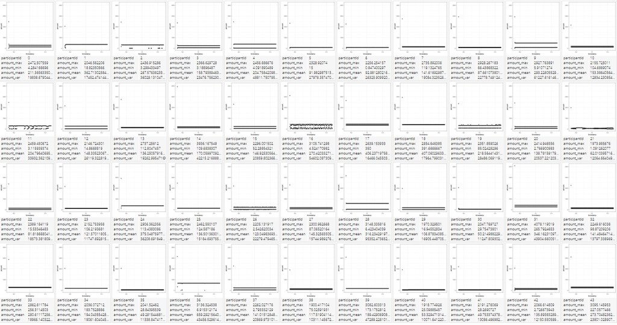

Wage seems to largely follow a uniform distribution on a per-participant basis.

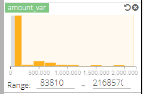

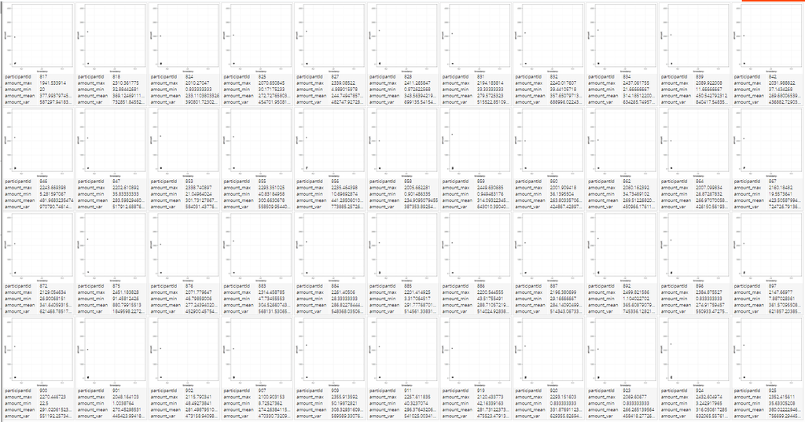

Most cases that are contributing to variance seem to be one-off changes in wages.

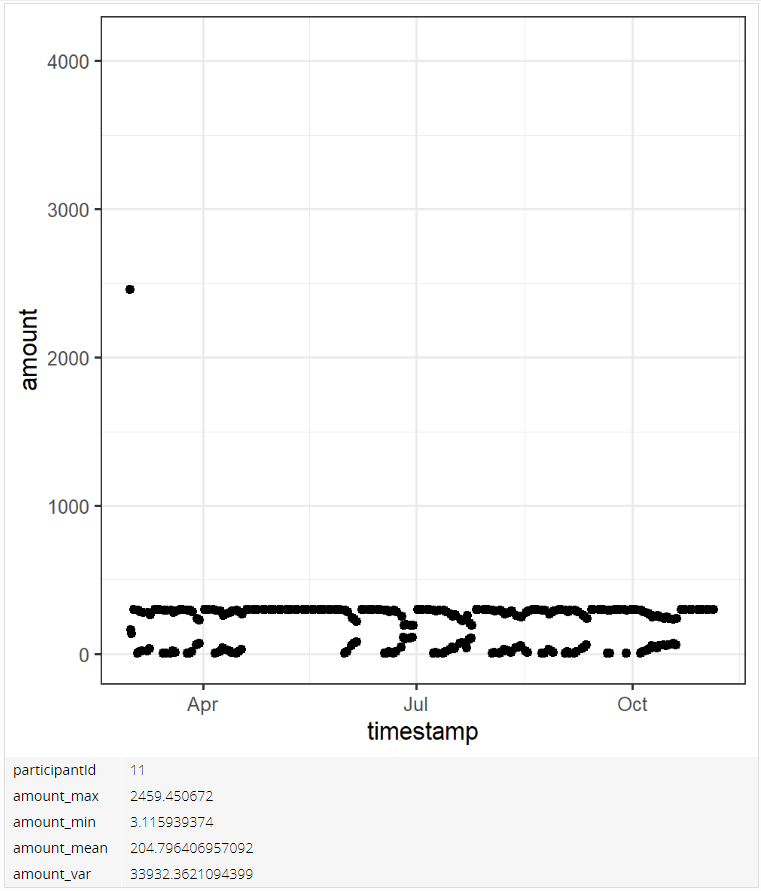

However, there are also cases where the change in income is more constant.

In general, the maximum income earned was $4096.52 and the least amount earned was $0.83.

## Expense

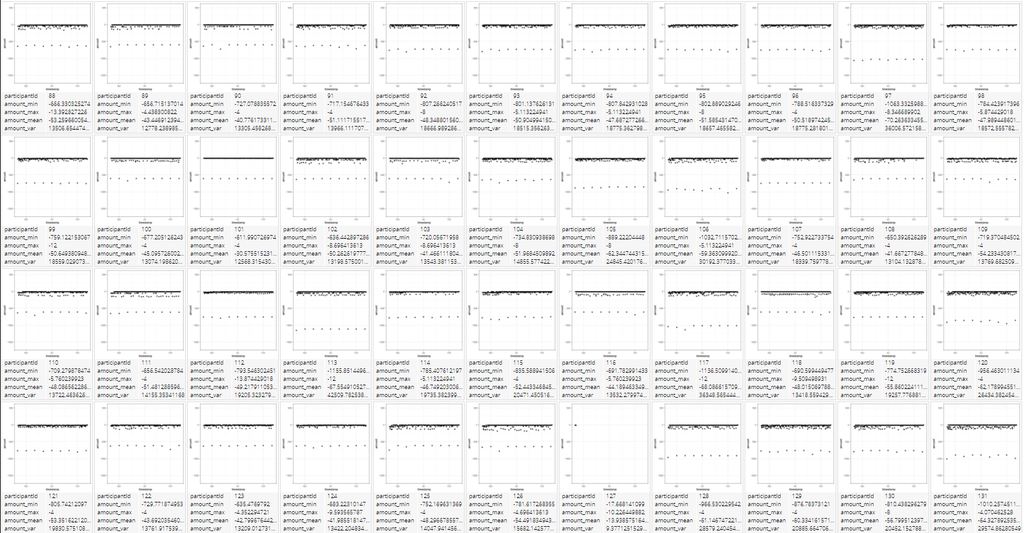

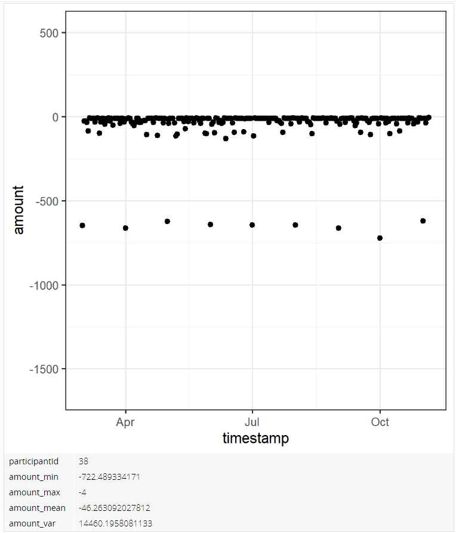

Combining the expenses shows that in general, there is a baseline amount spent each day by the participants, punctured by high amounts of spending.

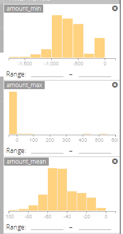

Overall, the largest expense is $1637.71 and the smallest expense is $9.92 on average.

### Education

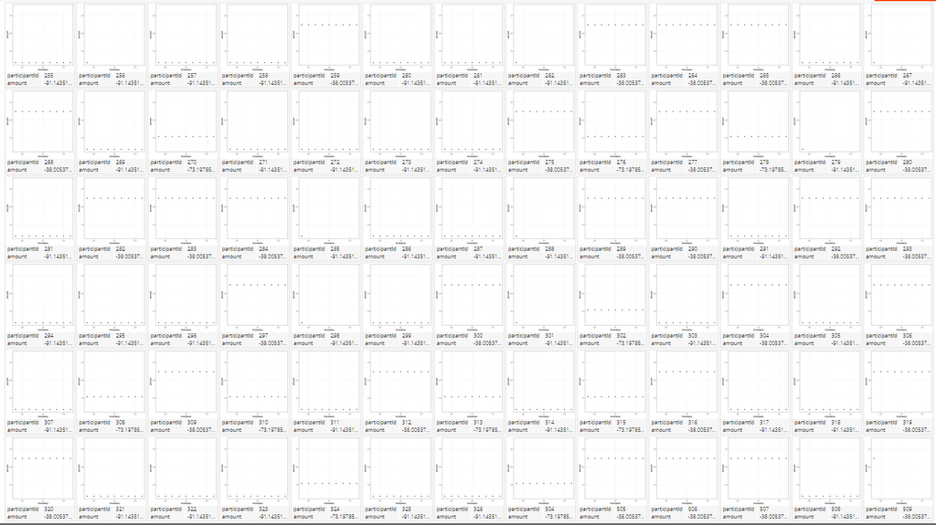

It looks like education expense follows a uniform distribution per participant.

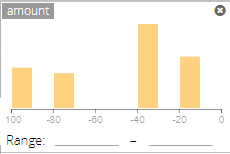

And that it is always part of a participant’s expense. A closer look show that it ranges from $12.81 to $91.14 on average.

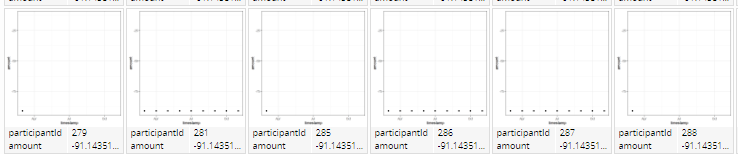

Lastly, it seems to be a one-time expense for certain users.

### Food

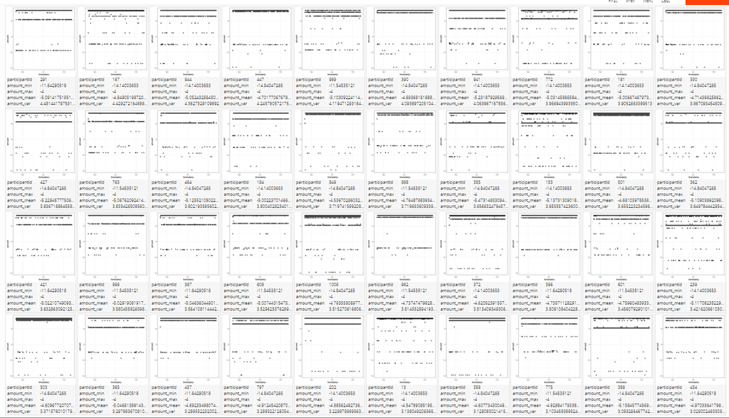

It would be premature for me to determine any form of distribution here based on Trelliscopejs plot.

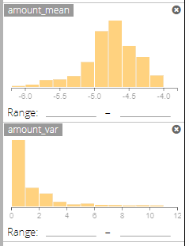

That being said, it seems to centre around $4.75 and have minimal variance. Also, the most spent on food is $14.84 and the least spent is $4.22 on average.

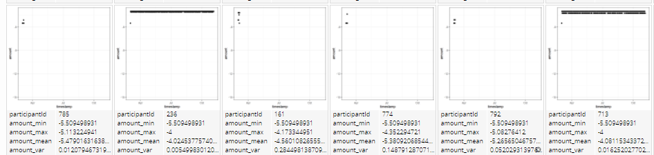

It is also interesting to note that food is a one-time expense for some participants.

### Recreation

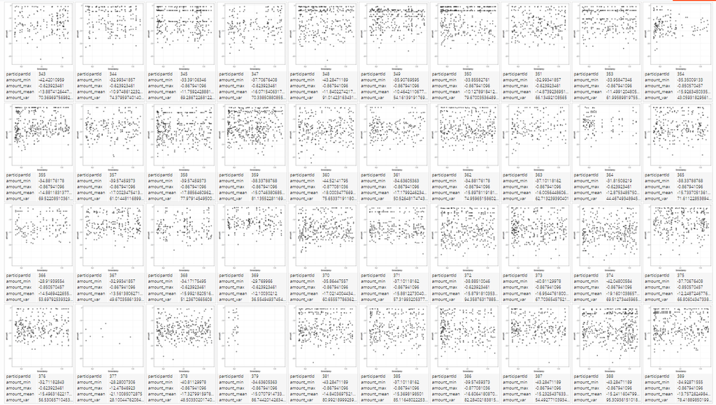

It would be premature for me to determine any form of distribution here based on Trelliscopejs plot.

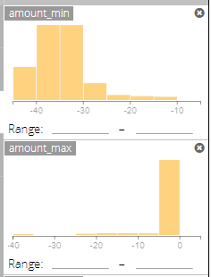

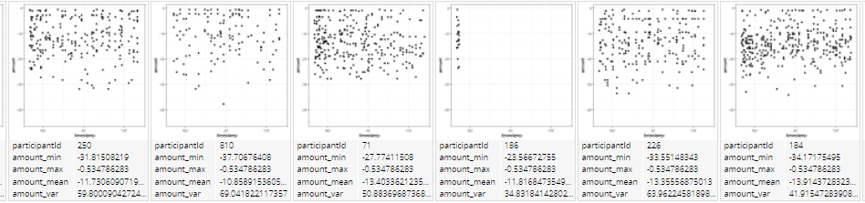

In addition, there are instances of participants where recreation is a one-time expense.

### Shelter

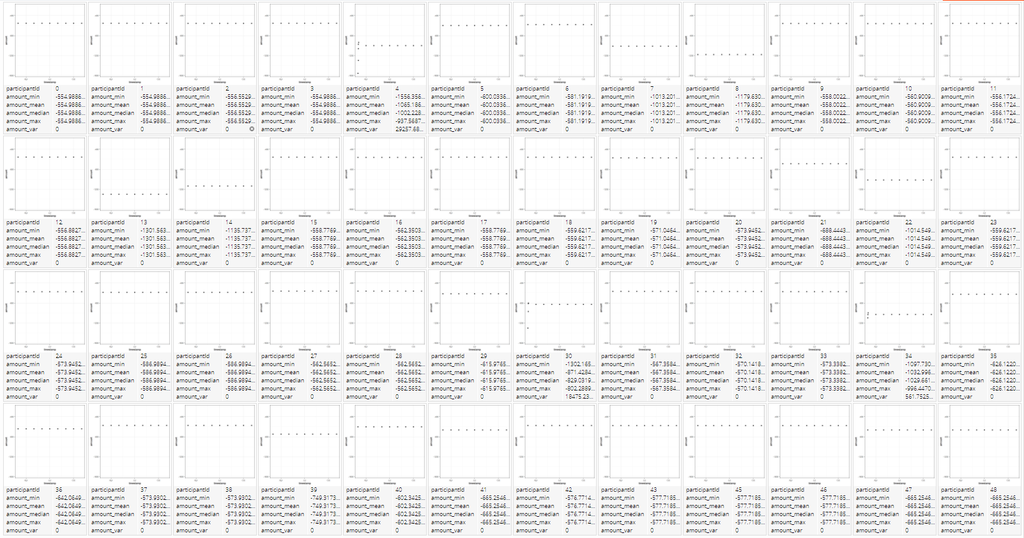

In general, shelter seems to follow a uniform distribution per participant as well.

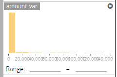

That being said, it seems to have some sort of variance.

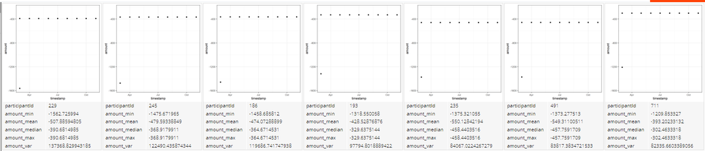

Upon closer inspection, it seems to be because of a one-time upgrade by certain participants.

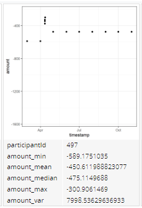

However, there are also cases where there is more than one change in shelter expense. These participants could be renters. However, it is also to be noted that they are the minority.

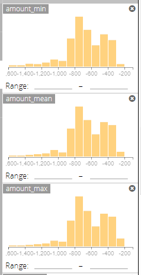

## Basic Conclusion and Steps Moving Forward

We now have an understanding of the income and expenses of participants in Engagmement.

1. There seem to be “dud” values where the participant just trails off and does not have any income or expense information over some period of time. And in most cases, once the participant trails off, no new data will be found. In the case of income, it could mean that the participant has stopped working. In the case of expense, a stop in recreation expense is fine. However, it is difficult to account for a stop in shelter, education and especially food expense.
2. Income is constant for almost all participants. So is education expense and shelter expense. Hence, most volatity in a participant’s available balance will be due to changes in other expenses.
3. The exploration so far does not investigate the relationship between income and expense.

# More Exploration

I focus on evaluating the difference between income and expense here.

## Getting Data

The goal here is to create a dataframe with expense, income and balance.

First, we convert the *wageIncome* dataframe so that it uses the same timestamps as the *allExpense* dataframe using the code chunk below.

```r
# Create a new data.frame with the newly formatted date field
wageIncome <- wageIncome %>%
  mutate(timestamp = as.Date(timestamp, format = "%m/%d/%y"))
head(wageIncome)
```

```
# A tibble: 6 x 4
  participantId timestamp  category amount
          <dbl> <date>     <chr>     <dbl>
1             0 2022-03-01 Wage      2473.
2             1 2022-03-01 Wage      2047.
3             2 2022-03-01 Wage      2437.
4             3 2022-03-01 Wage      2367.
5             4 2022-03-01 Wage      2457.
6             5 2022-03-01 Wage      2329.
```

We change the column names too with the following code chunk. Also, we need to find out if they have the same number of rows

```r
colnames(wageIncome) <- c('participantId','timestamp','income', 'incomeAmount')

colnames(allExpense) <- c('participantId','timestamp','expenseAmount')

nrow(wageIncome)
```

```
[1] 283434
```

```r
nrow(allExpense)
```

```
[1] 220617
```

We also group all wages so that there is at most 1 wage datapoint for each timestamp.

```r
# Create a new data.frame with the newly formatted date field
wageIncome <- wageIncome %>%
  group_by(participantId, timestamp) %>%
  summarise(incomeAmount = sum(incomeAmount, na.rm = TRUE))
```

Now we create a completely new dataframe using the *wageIncome* and *allExpense* dataframes with the code chunk below.

```r
# Given that wageIncome has more rows, we left-join into that

incomeAndExpenseTable <- merge(x = wageIncome, y = allExpense, c("participantId", "timestamp"), all.x = TRUE)
head(incomeAndExpenseTable)
```

```
  participantId  timestamp incomeAmount expenseAmount
1             0 2022-03-01     2883.788   -620.582943
2             0 2022-03-02      411.280    -25.045203
3             0 2022-03-03      411.280    -29.437606
4             0 2022-03-04      411.280    -26.885895
5             0 2022-03-07      411.280     -8.173345
6             0 2022-03-08      411.280     -8.173345
```

Lastly, we add a balance column to the datafame.

```r
incomeAndExpenseTable <- incomeAndExpenseTable %>%
  mutate(balance = incomeAmount + expenseAmount)
head(incomeAndExpenseTable)
```

```
  participantId  timestamp incomeAmount expenseAmount   balance
1             0 2022-03-01     2883.788   -620.582943 2263.2046
2             0 2022-03-02      411.280    -25.045203  386.2348
3             0 2022-03-03      411.280    -29.437606  381.8424
4             0 2022-03-04      411.280    -26.885895  384.3941
5             0 2022-03-07      411.280     -8.173345  403.1067
6             0 2022-03-08      411.280     -8.173345  403.1067
```

To create a Trelliscopejs plot for each participant’s balance, we first create a dataet for balance

```r
# Get all balance related data
allBalance <- data.frame(incomeAndExpenseTable$participantId, incomeAndExpenseTable$timestamp, incomeAndExpenseTable$balance)
head(allBalance)
```

```
  incomeAndExpenseTable.participantId incomeAndExpenseTable.timestamp
1                                   0                      2022-03-01
2                                   0                      2022-03-02
3                                   0                      2022-03-03
4                                   0                      2022-03-04
5                                   0                      2022-03-07
6                                   0                      2022-03-08
  incomeAndExpenseTable.balance
1                     2263.2046
2                      386.2348
3                      381.8424
4                      384.3941
5                      403.1067
6                      403.1067
```

Now, we create the Trelliscopejs plot.

```r
# For total expense
qplot(incomeAndExpenseTable.timestamp, incomeAndExpenseTable.balance, data = allBalance) +
  theme_bw() +
  facet_trelliscope(~ incomeAndExpenseTable.participantId,
                    nrow = 2,
                    ncol = 5,
                    path = "trellisbal/",
                    self_contained = TRUE)
```

# More Insights

## Balance

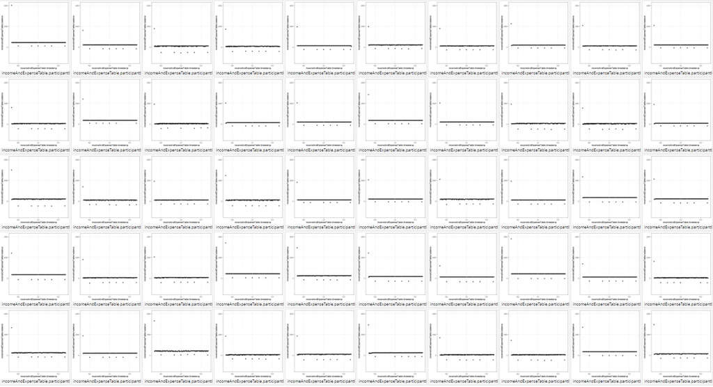

Balance seems to have a uniform distribution for each participant.

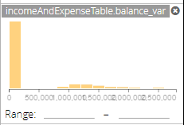

This backed up by the low variance as variance tends to center around 0.

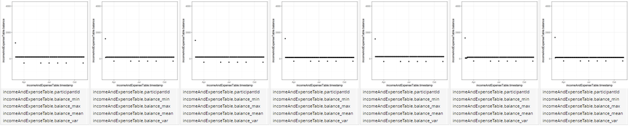

Also, most variance seems to come from occasional changes in balance.

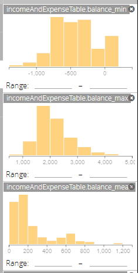

While i cannot tell as much from these tables, it is important to note that some people do go into debt. The lowest balance is $-1335.67 while the highest balance is $4081.58.